# Intel Image Classification

The intel image classification problem concerned predicting the class of images grouped into six classes (buildings, forest, glacier, mountain, sea and street). We will initially train a simple neural network with a single 2D convoutional layer and use training imags without augmentation before training the model using the ResNet50 pre-trained model and training data with augmented images.

## Import Libraries

```python
from keras.models import Sequential
import keras
from keras.layers import Conv2D, MaxPooling2D
from keras.layers import Activation, Dropout, Flatten, Dense
from keras.preprocessing.image import ImageDataGenerator
from keras import layers, optimizers
import numpy as np
import pandas as pd
import matplotlib.pyplot as plt
import matplotlib.image as mpimg
%matplotlib inline
```

## Benchmark Model

Create a simple neural network without image augmentation to serve as a benchmark for the more complex model that we'll train later.

#### Define Neural Network

```python
benchmark_model = Sequential()
benchmark_model.add(layers.Conv2D(32,(3,3),activation='relu', input_shape=(150,150,3)))
benchmark_model.add(layers.MaxPooling2D((2,2)))
benchmark_model.add(layers.Flatten())
benchmark_model.add(Dense(6))
benchmark_model.add(Activation('softmax'))
```

```
WARNING:tensorflow:From /home/paperspace/anaconda3/lib/python3.7/site-packages/tensorflow/python/framework/op_def_library.py:263: colocate_with (from tensorflow.python.framework.ops) is deprecated and will be removed in a future version.
Instructions for updating:
Colocations handled automatically by placer.
```

#### Define Data Generators

```python
train_directory = 'seg_train'
val_directory = 'seg_val'
test_directory = 'seg_test'
```

```python
batch_size = 16
non_aug_generator = ImageDataGenerator(
    rescale=1./255)
```

```python
benchmark_train_generator = non_aug_generator.flow_from_directory(
        train_directory,
        target_size=(150,150),
        batch_size = batch_size,
        class_mode='categorical'
)
val_generator = non_aug_generator.flow_from_directory(
        val_directory,
        target_size=(150,150),
        batch_size = batch_size,
        class_mode='categorical'
)
test_generator =  non_aug_generator.flow_from_directory(
        test_directory,
        shuffle = False,
        target_size=(150,150),
        batch_size = 1,
        class_mode='categorical'
)
```

```
Found 11224 images belonging to 6 classes.
Found 2810 images belonging to 6 classes.
Found 3000 images belonging to 6 classes.
```

#### Compile Model

```python
benchmark_model.compile(loss='categorical_crossentropy',
             optimizer=optimizers.Adam(lr=0.0001),
             metrics=['accuracy'])
```

#### Define Early Stopping

To stop trainning if validation accuracy hasn't improved after 5 epochs

```python
callback = [keras.callbacks.EarlyStopping(monitor='val_acc', patience=5)]
```

#### Train Model

```python
benchmark_training = benchmark_model.fit_generator(
    benchmark_train_generator,
    steps_per_epoch=2000 // batch_size,
    epochs = 100,
    callbacks = callback,
    validation_data = val_generator,
    validation_steps = 800 // batch_size
)
```

```
WARNING:tensorflow:From /home/paperspace/anaconda3/lib/python3.7/site-packages/tensorflow/python/ops/math_ops.py:3066: to_int32 (from tensorflow.python.ops.math_ops) is deprecated and will be removed in a future version.
Instructions for updating:
Use tf.cast instead.
```

#### Plot Model Performance on Train & Validation Data

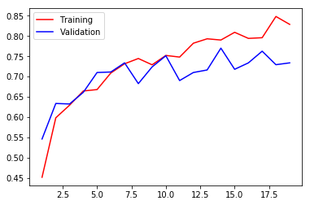

```python
acc = benchmark_training.history['acc']
val_acc = benchmark_training.history['val_acc']

epochs = range(1,len(acc) + 1)

plt.plot(epochs, acc, 'r',label='Training')
plt.plot(epochs, val_acc, 'b', label='Validation')
plt.legend()
plt.figure()
plt.show()
```

#### Make Prediction on Test Set

```python
test_step_size=test_generator.n//test_generator.batch_size
test_generator.reset()
benchmark_pred=benchmark_model.predict_generator(test_generator,
    steps=test_step_size,
    verbose=1)
```

#### Analyse Model Performance on Test Set

```python
def pred_results(pred, train_generator):
    predicted_class_indices=np.argmax(pred,axis=1)
    labels = (train_generator.class_indices)
    labels = dict((v,k) for k,v in labels.items())
    predictions = [labels[k] for k in predicted_class_indices]
    filenames=test_generator.filenames
    results=pd.DataFrame({"Filename":filenames,
                          "Predictions":predictions})
    get_actuals = lambda x : x['Filename'].split('/')[0]
    results['actuals'] = results.apply(get_actuals, axis=1)
    results['correct'] = results.apply(lambda x: 1 if x['Predictions'] == x['actuals'] else 0, axis=1)
    correct = results['correct'].sum()
    total = results['Filename'].count()
    success_rate = correct/total
    return success_rate, results
bm_success_rate, bm_results = pred_results(benchmark_pred, benchmark_train_generator)
```

```python
print('Benchmark Success Rate:' + str(bm_success_rate))
```

```
Benchmark Success Rate:0.7143333333333334
```

## Residual Model

We will now train a model using the ResNet50 architecture and compare this more complex model to the benchmark model

#### Import ResNet50, Define & Compile Model

We intialise the ResNEt50 model with weights derived from training on the imagenet data set however we will re-train the model but with a small learning rate

```python
from keras.applications.resnet50 import ResNet50
res_model = ResNet50(weights='imagenet', include_top=False, input_shape=(150,150,3))
res_model.trainable = True
```

```python
model = Sequential()
model.add(res_model)
model.add(Flatten())
model.add(Dropout(0.5))
model.add(layers.Dense(256, activation='relu'))
model.add(Dense(6))
model.add(Activation('softmax'))
model.summary()
```

```
_________________________________________________________________
Layer (type)                 Output Shape              Param #
=================================================================
resnet50 (Model)             (None, 5, 5, 2048)        23587712
_________________________________________________________________
flatten_3 (Flatten)          (None, 51200)             0
_________________________________________________________________
dropout_2 (Dropout)          (None, 51200)             0
_________________________________________________________________
dense_4 (Dense)              (None, 256)               13107456
_________________________________________________________________
dense_5 (Dense)              (None, 6)                 1542
_________________________________________________________________
activation_101 (Activation)  (None, 6)                 0
=================================================================
Total params: 36,696,710
Trainable params: 36,643,590
Non-trainable params: 53,120
_________________________________________________________________
```

```python
model.compile(loss='categorical_crossentropy',
             optimizer=optimizers.Adam(lr=0.0001),
             metrics=['accuracy'])
```

#### Data Generator with Image Augmentation

```python
aug_generator = ImageDataGenerator(
    rescale=1./255,
    rotation_range=40,
    width_shift_range=0.2,
    height_shift_range=0.2,
    shear_range=0.2,
    zoom_range=0.2,
    horizontal_flip=True)
```

```python
train_generator = aug_generator.flow_from_directory(
        train_directory,
        target_size=(150,150),
        batch_size = batch_size,
        class_mode='categorical'
)
```

```
Found 11224 images belonging to 6 classes.
```

#### Train Model

```python
training = model.fit_generator(
    train_generator,
    steps_per_epoch=2000 // batch_size,
    epochs = 100,
    callbacks = callback,
    validation_data = val_generator,
    validation_steps = 800 // batch_size
)
```

#### Plot Model Performance on Train & Validation Data

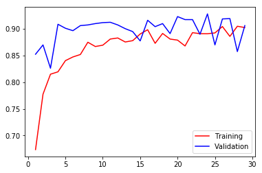

```python
acc = training.history['acc']
val_acc = training.history['val_acc']

epochs = range(1,len(acc) + 1)

plt.plot(epochs, acc, 'r',label='Training')
plt.plot(epochs, val_acc, 'b', label='Validation')
plt.legend()
plt.figure()
plt.show()
```

#### Make Prediction on Test Set

```python
test_step_size=test_generator.n//test_generator.batch_size
test_generator.reset()
pred=model.predict_generator(test_generator,
steps=test_step_size,
verbose=1)
```

#### Analyse Model Performance on Test Set

```python
success_rate, results = pred_results(pred, train_generator)
```

```python
print('Final Model Success Rate:' + str(success_rate))
```

```
Final Model Success Rate:0.9056666666666666
```

#### Analyse Model Errors

```python
errors = results[results['correct'] == 0]
```

```
Actual:buildings
Prediction:street
```

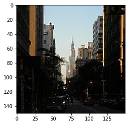

```python
index = 2
img=mpimg.imread('seg_test/' + errors['Filename'].iloc[index])
print('Actual:' + errors['actuals'].iloc[index])
print('Prediction:' + errors['Predictions'].iloc[index])
plt.imshow(img)
```

#### Conclusion

Using ResNet50 architecture with image augmentation enabled an improvement from 71.4% to 90.5% in accuracy on the test set. Looking at the images that were not classified correctly in the test set, it's clear that many of these contain elements from other classes such as the above image that had a building label but contains aspects of a street in the image that was obviously what the model used in it's classification.

For future iterations of the model we can look to try some or all of the following to improve accuracy:

- Tune the learning rate
- Try different image augmentation
- Try different pre-trained models with different layers frozen